# Data-analytiikka - Harjoitus 8

Huomaa, että tehtävät tulee palauttaa html-tiedostona, jossa näkyvät sekä koodisolujen sisällöt että tulosteet. Notebookin saat html-tiedostoksi valitsemalla File -> Download as -> HTML. Tehtävien vastaukset voi tehdä yhteen tai useampaan koodisoluun.

**Opiskelijan nimi**: Pyry Anttila

**Opiskelijanumero**: AD0828

## Subplots

Kuvaajien vertailtavuuden helpottamiseksi kuvaajia kannattaa opetella ryhmittelemään vierekkäin ja allekain. Tässä tehtävässä opetellaan tekemään piirakkakaavio ja asettamaan kaksi kuvaajaa vierekkäin.

Lue datasetti 'cybersecyrity_attacks.csv' DataFrameen urlista https://student.labranet.jamk.fi/~ajota/Datasets/cybersecurity_attacks.csv.

Tee seuraavat kaaviot samaan kuvaan vierekkäin, mallin näet alla.

1. Visualisoi piirakkakaavioon eri hyökkäystyyppien prosentuaaliset osuudet datasetissä.
2. Visualisoi pylväskaavioon hyökkäystyypin 'Malware' lukumäärät kuukausittain vuonna 2022. (Vinkki: Tee ensin "Timestamp"-sarakkeesta uudet sarakkeet "Year" ja "Month" ja lähde suodattamaan ja ryhmittelemään dataa näiden avulla.

[figure not shown]

Pisteytys: 1 p

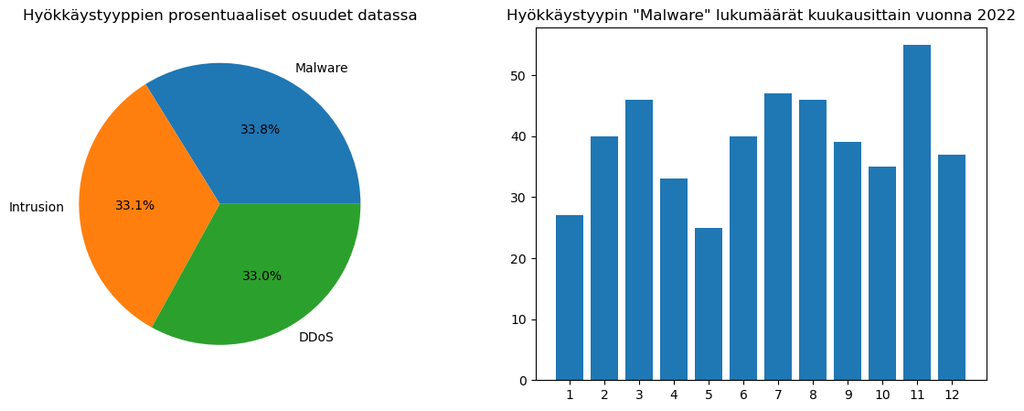

```python
# Vastaus
import pandas as pd
import matplotlib.pyplot as plt

df = pd.read_csv('https://student.labranet.jamk.fi/~ajota/Datasets/cybersecurity_attacks.csv', index_col=0)

# Datan käsittely
df['Timestamp'] = pd.to_datetime(df['Timestamp'])

df['Year'] = df['Timestamp'].dt.year
df['Month'] = df['Timestamp'].dt.month

atcount = df['Attack Type'].value_counts()
atpercentage = atcount / atcount.sum() * 100

malware = df[(df['Year'] == 2022) & (df['Attack Type'] == 'Malware')].groupby('Month').size()

# Kuvaajat
fig, axes = plt.subplots(1, 2, figsize=(14, 5))

axes[0].pie(atpercentage, labels=atpercentage.index, autopct='%1.1f%%')
axes[0].set_title('Hyökkäystyyppien prosentuaaliset osuudet datassa')

axes[1].bar(malware.index, malware.values)
axes[1].set_title('Hyökkäystyypin "Malware" lukumäärät kuukausittain vuonna 2022')

axes[1].set_xticks(range(1, 13))

plt.show()
```

## Uudelleen näytteistäminen

Toisinaan aikasarjadatasta puuttuu sopiva näytteistysväli, jotta data saataisiin järkevästi visualisoitua. Tällöin voi kokeilla uudelleen näytteistämistä.

Tiedostossa 'dos_attack_unsw_nb15.csv' on synteettistä, tutkimustarkoituksiin luotua dataa, joka kuvaa DoS-hyökkäyksiä. Voit lukea datan urlista 'https://student.labranet.jamk.fi/~ajota/Datasets/dos_attack_unsw_nb15.csv'

Visualisoi yhteyksien määrä ajan suhteen. Aikana voit käyttää 'record start time' -saraketta ja yhteydenottojen lukumäärän laskea esimerkiksi 'Source IP address' -sarakkeen avulla.

Mieti/testaa järkevä näytteistysväli, (5 s, 10 s, 30 s, 60 s) jolla yhteydenottojen määrää kannattaa visualisoida.

Alla malliksi uudelleen näytteistyss 30 s välein.

[figure not shown]

Pisteytys: 1 p

```python
import pandas as pd
url = 'https://student.labranet.jamk.fi/~ajota/Datasets/dos_attack_unsw_nb15.csv'
df_dos = pd.read_csv(url, index_col=0)
```

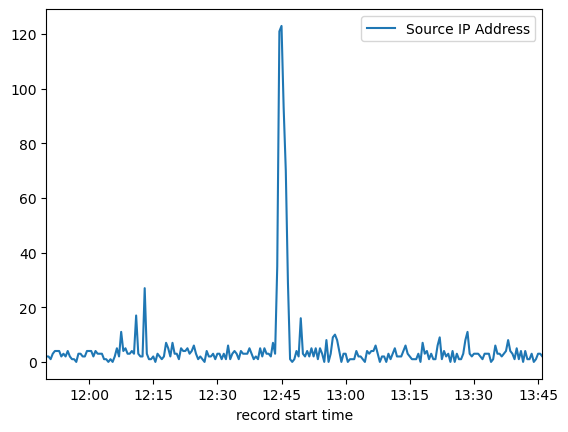

```python
# Vastaus
import matplotlib.dates as mdates

# Datan käsittely
df_dos['record start time'] = pd.to_datetime(df_dos['record start time'])

df_dos.set_index('record start time', inplace=True)
connections_count = df_dos.resample('30s').agg({'Source IP address': 'count'})

# Kuvaaja
plt.plot(connections_count.index, connections_count['Source IP address'], label='Source IP Address')

ax = plt.gca()
ax.xaxis.set_major_formatter(mdates.DateFormatter('%H:%M'))

plt.xlabel('record start time')
plt.margins(x=0)
plt.legend()
plt.show()
```

# Aikasarjadatan visualisointia

Lue tiedosto 'rba-dataset_january2021.csv' dataframeen osoitteesta 'https://student.labranet.jamk.fi/~ajota/Datasets/rba-dataset_january2021.csv'. (Jos datan määrä osoittautuu ylitsepääsemättömäksi ongelmaksi, voit lukea datasta käyttöön vain osan. Alkuperäinen datasetti ja tietojen kuvaukset löytyy mm. Kagglesta https://www.kaggle.com/datasets/dasgroup/rba-dataset)

Visualisoi datasta onnistuneiden ja epäonnistuneiden kirjautumisyritysten määrä päivittäin tuntitasolla alla olevan esimerkin mukaisesti. X-akselilla tulee näkyä päivämäärä ja kellonaika. Päivämäärän ja kellonajan muotoilu saa poiketa esimerkistä.

[figure not shown]

Vaikka kyseessä on synteettinen datasetti ja datan määrää on jouduttu reippaasti karsimaan tätä tehtävää varten (eikä data siten kaikilta osin vastaisi todellisuutta), pohdi seuraavia asioita:

- Keskittyvätkö kirjausyritykset tietyille päiville tai tunneille? Mikä selittää tätä?
- Onko datassa havaittavissa trendejä tai kausivaihtelua?
- Miten onnistuneiden ja epäonnistuneiden kirjautumisyritysten piikit vertautuvat toisiinsa? Löytyykö tekemällesi havainnolle jokin luonnollinen selitys?
- Mikä voisi selittää kuvaajan alussa näkyvää suurta epäonnistuneiden kirjautumisyritysten määrää (lukumäärissä näkyy tuntikohtainen vaihtelu ja lukumäärät ovat tasaisesti "koholla" verrattuna kuvaajassa näkyvään myöhempään ajanjaksoon)?

Pisteytys: Kuvaaja 1 p + pohdinta 0.5 p

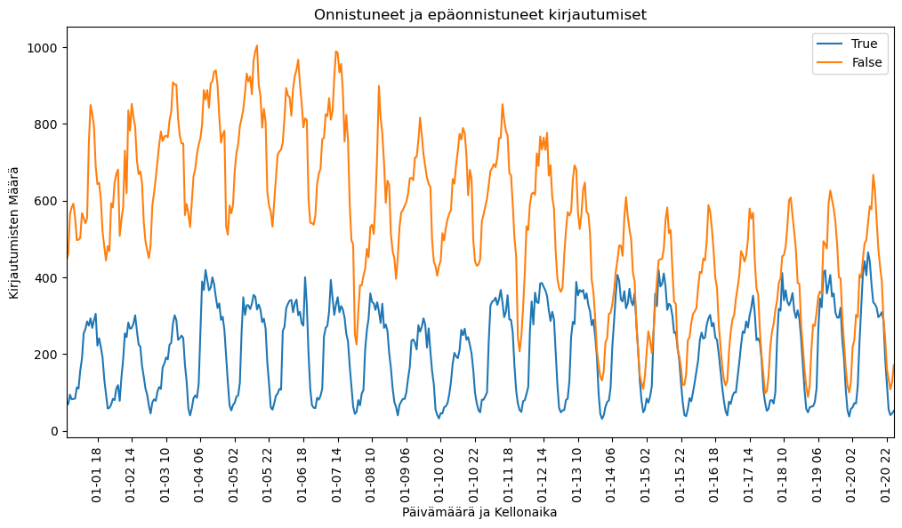

```python
import matplotlib.dates as mdates

df_rpa = pd.read_csv('https://student.labranet.jamk.fi/~ajota/Datasets/rba-dataset_january2021.csv', index_col=0)

# Datan käsittely
df_rpa['Login Timestamp'] = pd.to_datetime(df_rpa['Login Timestamp'])

df_rpa.set_index('Login Timestamp', inplace=True)

successful_logins = df_rpa.resample('h')['Login Successful'].sum()
unsuccessful_logins = df_rpa.resample('h')['Login Successful'].apply(lambda x: (x == False).sum())

login_counts = pd.DataFrame({'True': successful_logins,'False': unsuccessful_logins}).fillna(0)

# Kuvaaja
plt.figure(figsize=(12, 6))
plt.plot(login_counts.index, login_counts['True'], label='True')
plt.plot(login_counts.index, login_counts['False'], label='False')

ax = plt.gca()
ax.xaxis.set_major_locator(mdates.HourLocator(interval=20))
ax.xaxis.set_major_formatter(mdates.DateFormatter('%m-%d %H'))

plt.title('Onnistuneet ja epäonnistuneet kirjautumiset')
plt.xlabel('Päivämäärä ja Kellonaika')
plt.ylabel('Kirjautumisten Määrä')
plt.legend()
plt.xticks(rotation=90)
plt.margins(x=0)
plt.show()
```

Keskittyvätkö kirjausyritykset tietyille päiville tai tunneille? Mikä selittää tätä?

- Kirjausyritykset näyttävät noudattavan aika säännöllistä rytmiä. Mitään tiettyä päivää kuvaajan perusteella ei voi sanoa, mutta tunneista voi sanoa, että päiväsaikaan tulee enemmän.

Onko datassa havaittavissa trendejä tai kausivaihtelua?

Miten onnistuneiden ja epäonnistuneiden kirjautumisyritysten piikit vertautuvat toisiinsa? Löytyykö tekemällesi havainnolle jokin luonnollinen selitys?

- Onnistuneiden ja epäonnistuiden kirjautumismäärät nousevat ja laskevat säännölliseti ja se johtuu todennäköisesti, että käyttäjämäärät ovat siihen aikaan pienemmät, sillä ihmiset ovat nukkumassa.

Mikä voisi selittää kuvaajan alussa näkyvää suurta epäonnistuneiden kirjautumisyritysten määrää (lukumäärissä näkyy tuntikohtainen vaihtelu ja lukumäärät ovat tasaisesti "koholla" verrattuna kuvaajassa näkyvään myöhempään ajanjaksoon)?

- Mahdollisesti ollut jokin iso tietomurto ja se oli johtanut bruteforce hyökkäyksiin eri palveluissa.